# Analysis of Quality of Red Wines by Ajay Das

# Multivariate Plots Section

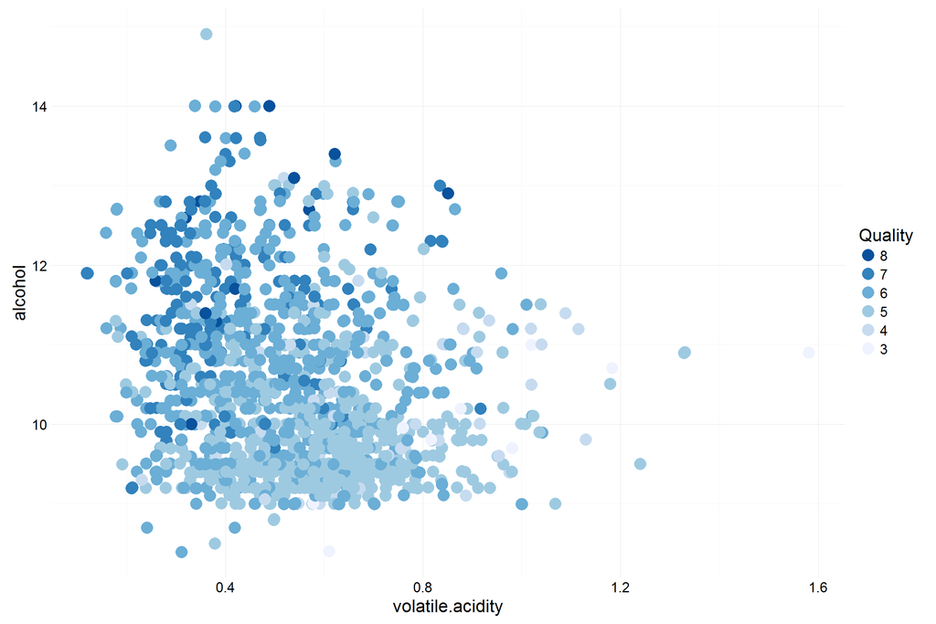

The color separation in the plot points supports my observation that a good quality wine has a higher alcohol content and low volatile acidity.

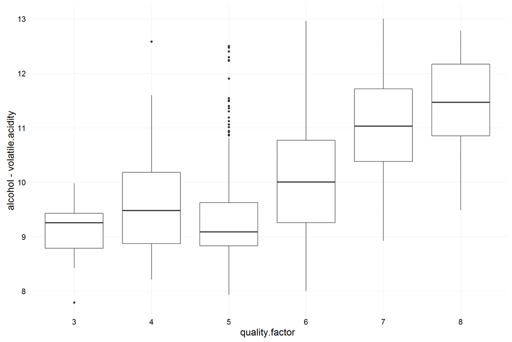

The boxplot is created for (alcohol-volatile acidity) to compound the effect of both alcohol and volatile acidity. This again helps visualize that high quality wines have high alcohol and low volatile acidity.

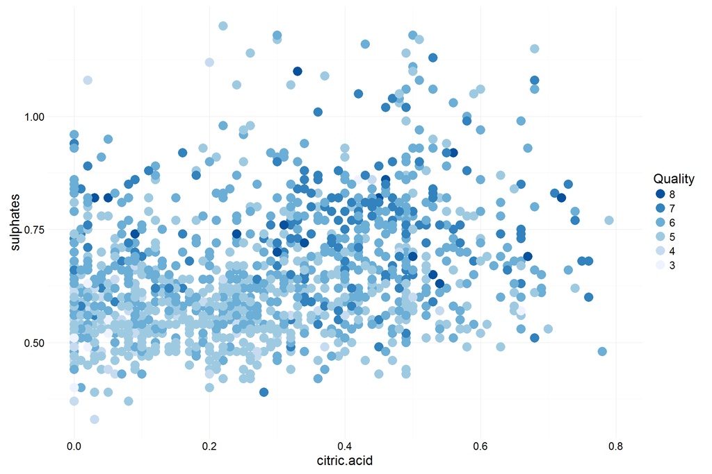

After eliminating outliers I can see that there is no strong separation of the colors but the colors do indicate that most high quality wines tend to have higher content of sulphates and citric acid.

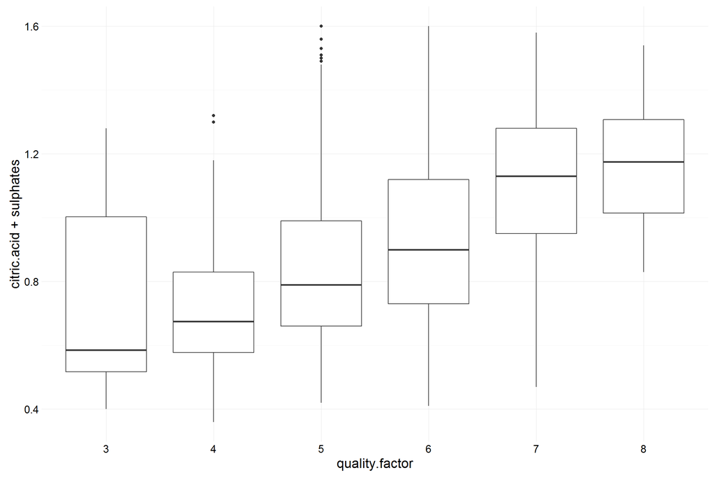

The boxplot is created for (citric acid + sulphates) to compound the effect of both citric acid and sulphates. This again helps visualize that high quality wines have high amount of citric acid and sulphates.

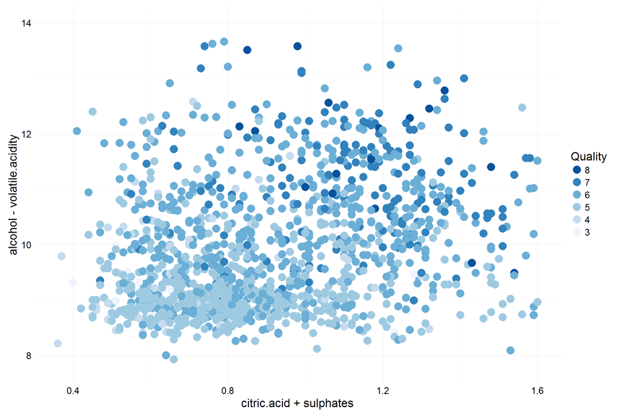

This plot brings all the four variables together and displays that the good quality wines populate the top right corner of the scatter plot.

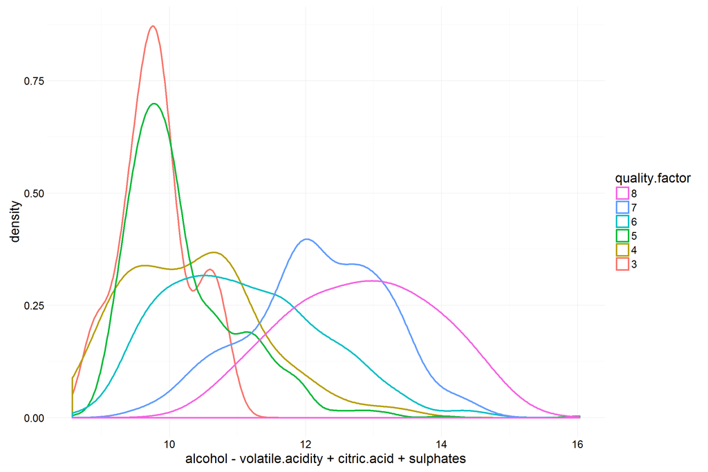

This density plot shows a clear sepatation around 11 separates higer quality wines than lower quality ones.

I will look at few more relationships that may not have impact on the main analysis but probably interesting:

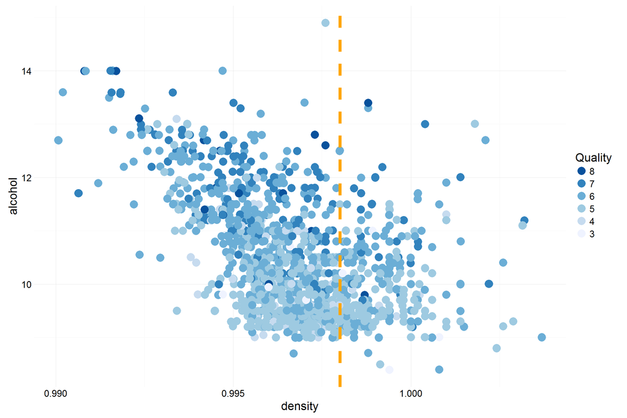

Alcohol is correlated with density at -0.5, which led me to explore the distribution of quality given a scatter plot of alcohol and density. Although good quality wines are found more at the top left area of the chart, there are some good quality wines that are found in the right side of the plot as well. The orange dashed line indicates the density of water at 20 degrees C. Alcohol is less dense than water, so keeping other factors constant higher alcohol would usually mean lower density. There may be other factors involved which pushed higher density for some wines with high alcohol.

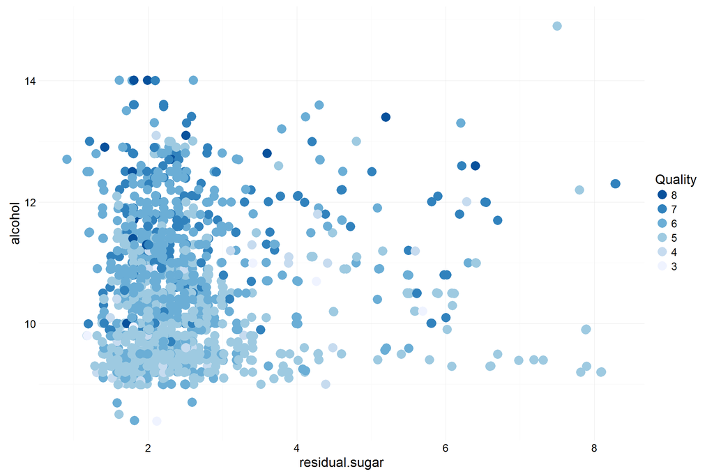

In wine making sugar is converted to alcohol by fermentation process. It can be expected that more alcohol content could mean low residual sugar. So I wanted to look at how the interaction between these two attributes contribute to quality. After eliminating top 1% residual sugar as outliers I noticed from the plot that most of the wines have low residual sugar regardless of the alcohol content. This may mean that wine makers make use of most of the sugar in the grapes to increase the alcohol content and the proportion of alcohol and residual sugar depends on initial sugar content in the grapes.

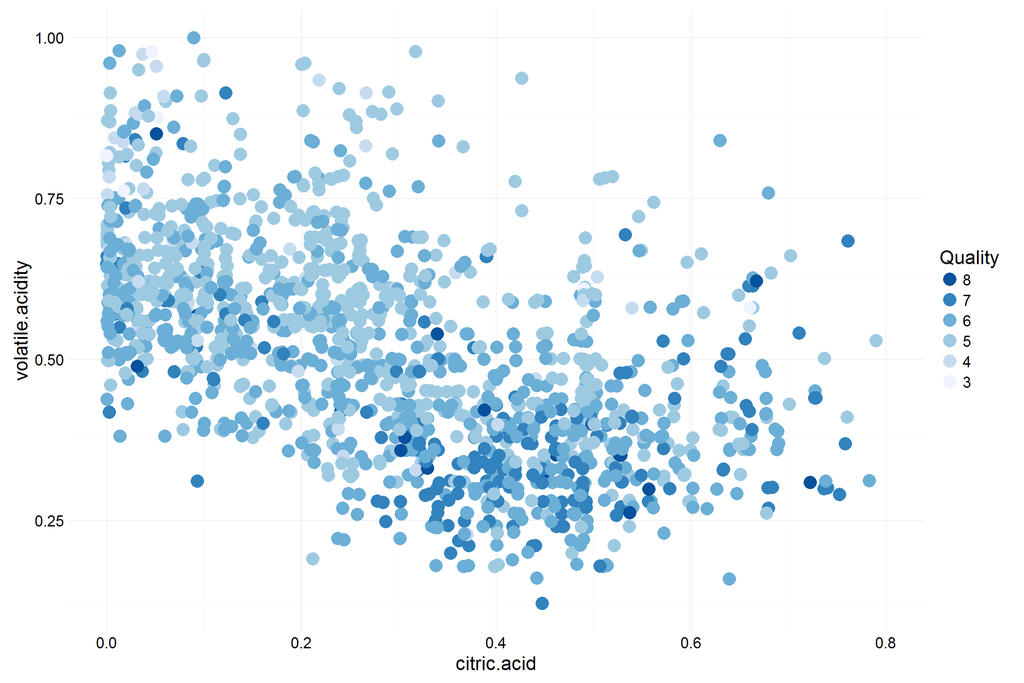

Citric acid and volatile acidity have a correlation coefficient of -0.55. From the scatter plot I can see that the good quality wines cluster around the bottom right corner.

```
##
## Calls:
## m1: lm(formula = quality ~ alcohol, data = reds)
## m2: lm(formula = quality ~ alcohol + volatile.acidity, data = reds)
## m3: lm(formula = quality ~ alcohol + volatile.acidity + sulphates,
##     data = reds)
## m4: lm(formula = quality ~ alcohol + volatile.acidity + sulphates +
##     citric.acid, data = reds)
##
## ================================================================
##                        m1         m2         m3         m4
## ----------------------------------------------------------------
##   (Intercept)        1.875***   3.095***   2.611***   2.646***
##                     (0.175)    (0.184)    (0.196)    (0.201)
##   alcohol            0.361***   0.314***   0.309***   0.309***
##                     (0.017)    (0.016)    (0.016)    (0.016)
##   volatile.acidity             -1.384***  -1.221***  -1.265***
##                                (0.095)    (0.097)    (0.113)
##   sulphates                                0.679***   0.696***
##                                           (0.101)    (0.103)
##   citric.acid                                        -0.079
##                                                      (0.104)
## ----------------------------------------------------------------
##   R-squared             0.227      0.317      0.336      0.336
##   adj. R-squared        0.226      0.316      0.335      0.334
##   sigma                 0.710      0.668      0.659      0.659
##   F                   468.267    370.379    268.912    201.777
##   p                     0.000      0.000      0.000      0.000
##   Log-likelihood    -1721.057  -1621.814  -1599.384  -1599.093
##   Deviance            805.870    711.796    692.105    691.852
##   AIC                3448.114   3251.628   3208.768   3210.186
##   BIC                3464.245   3273.136   3235.654   3242.448
##   N                  1599       1599       1599       1599
## ================================================================
```

The selected variables in the model explain 33.6 % of the variance. This is not very significant but it is good that we can explain some of the variances.

# Multivariate Analysis

### Talk about some of the relationships you observed in this part of the investigation. Were there features that strengthened each other in terms of looking at your feature(s) of interest?

In the Multivariate analysis, I used quality as a color for scatter plot points to identify if the good quality wines (of similar color) cluster together in certain areas of the plot. The first plot revealed that good quality wines do indeed cluster around high alcohol and low volatile acidity region. In the scatter plot for sulphates and citric acid the quality color codes are more dispersed but there is some indication of improving quality with increasing sulphates and citric acid. Combining all the variables together provides a good separation between high quality and low quality wines.

### OPTIONAL: Did you create any models with your dataset? Discuss the strengths and limitations of your model.

I created 4 models to predict the wine quality using variables added in sequence starting with alcohol then adding volatile acidity, sulphates and citric acid. Alcohol explains 22.7% of variance by itself and adding volatile acidity it goes up to 31.7%. By adding sulphates the model explains 33.6 % of variance. Adding citric acid does not help increase the effectiveness of the model as the interaction between volatile acidity and citric acid takes over.

The model is good at providing some indication of the attributes that may contribute to a good quality wine. This also supports some of the initial theory about the attributes. But R-squared value of 0.336 indicates that it is not a very good model for predicting wine quality. Quality rating of wine being a qualitative measure depending on subjective analysis of wine experts it is reasonable that most of the variance is not explained by the model.

# Final Plots and Summary

### Plot One

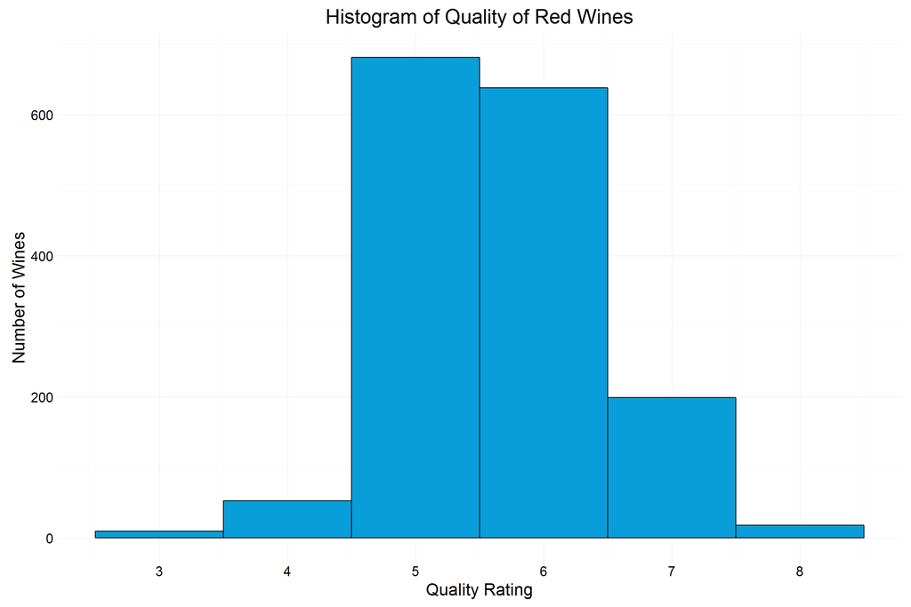

```
##   3   4   5   6   7   8
##  10  53 681 638 199  18
```

```
##    Min. 1st Qu.  Median    Mean 3rd Qu.    Max.
##   3.000   5.000   6.000   5.636   6.000   8.000
```

### Description One

This plot was selected to highlight the distribution of quality ratings across all the wine samples avaiable in the dataset and its possible impact on the study. From the histogram of the distribution of wine quality across the red wines in the dataset it can be seen that most of the wines have rating of 5 (681) and 6 (638). Together they account for 1319 out of 1599 (82.5%) of the wines. This uneven distribution can limit the effectiveness of the study to identify which of the 11 chemical attributes contribute to the quality ratings for each wine.

### Plot Two

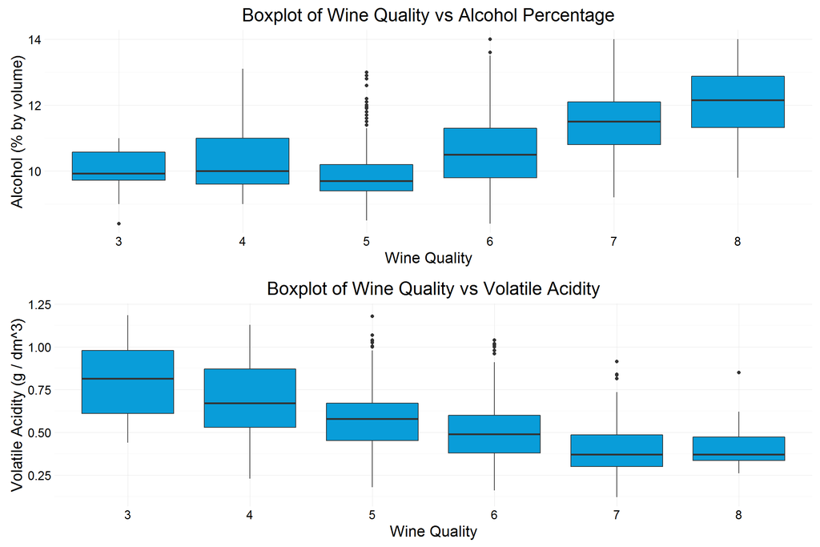

```
## reds$quality.factor: 3
##    Min. 1st Qu.  Median    Mean 3rd Qu.    Max.
##   8.400   9.725   9.925   9.955  10.580  11.000
## --------------------------------------------------------
## reds$quality.factor: 4
##    Min. 1st Qu.  Median    Mean 3rd Qu.    Max.
##    9.00    9.60   10.00   10.27   11.00   13.10
## --------------------------------------------------------
## reds$quality.factor: 5
##    Min. 1st Qu.  Median    Mean 3rd Qu.    Max.
##     8.5     9.4     9.7     9.9    10.2    14.9
## --------------------------------------------------------
## reds$quality.factor: 6
##    Min. 1st Qu.  Median    Mean 3rd Qu.    Max.
##    8.40    9.80   10.50   10.63   11.30   14.00
## --------------------------------------------------------
## reds$quality.factor: 7
##    Min. 1st Qu.  Median    Mean 3rd Qu.    Max.
##    9.20   10.80   11.50   11.47   12.10   14.00
## --------------------------------------------------------
## reds$quality.factor: 8
##    Min. 1st Qu.  Median    Mean 3rd Qu.    Max.
##    9.80   11.32   12.15   12.09   12.88   14.00
```

```
## reds$quality.factor: 3
##    Min. 1st Qu.  Median    Mean 3rd Qu.    Max.
##  0.4400  0.6475  0.8450  0.8845  1.0100  1.5800
## --------------------------------------------------------
## reds$quality.factor: 4
##    Min. 1st Qu.  Median    Mean 3rd Qu.    Max.
##   0.230   0.530   0.670   0.694   0.870   1.130
## --------------------------------------------------------
## reds$quality.factor: 5
##    Min. 1st Qu.  Median    Mean 3rd Qu.    Max.
##   0.180   0.460   0.580   0.577   0.670   1.330
## --------------------------------------------------------
## reds$quality.factor: 6
##    Min. 1st Qu.  Median    Mean 3rd Qu.    Max.
##  0.1600  0.3800  0.4900  0.4975  0.6000  1.0400
## --------------------------------------------------------
## reds$quality.factor: 7
##    Min. 1st Qu.  Median    Mean 3rd Qu.    Max.
##  0.1200  0.3000  0.3700  0.4039  0.4850  0.9150
## --------------------------------------------------------
## reds$quality.factor: 8
##    Min. 1st Qu.  Median    Mean 3rd Qu.    Max.
##  0.2600  0.3350  0.3700  0.4233  0.4725  0.8500
```

```
##
## Call:
## lm(formula = quality ~ alcohol + volatile.acidity, data = reds)
##
## Residuals:
##      Min       1Q   Median       3Q      Max
## -2.59342 -0.40416 -0.07426  0.46539  2.25809
##
## Coefficients:
##                  Estimate Std. Error t value Pr(>|t|)
## (Intercept)       3.09547    0.18450   16.78   <2e-16 ***
## alcohol           0.31381    0.01601   19.60   <2e-16 ***
## volatile.acidity -1.38364    0.09527  -14.52   <2e-16 ***
## ---
## Signif. codes:  0 '***' 0.001 '**' 0.01 '*' 0.05 '.' 0.1 ' ' 1
##
## Residual standard error: 0.6678 on 1596 degrees of freedom
## Multiple R-squared:  0.317,  Adjusted R-squared:  0.3161
## F-statistic: 370.4 on 2 and 1596 DF,  p-value: < 2.2e-16
```

### Plot Three

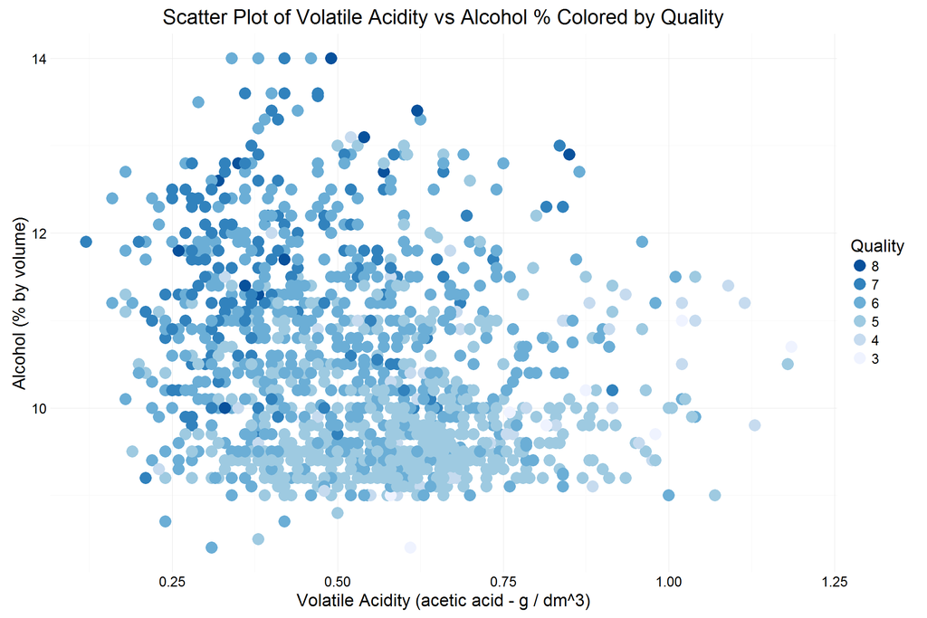

### Description Three

This final plot brings out the interaction between alcohol and volatile acidity through scatter plot and the coloring by quality helps identify if higher quality wines cluster together in a different part of the plot than the low quality wines. From the Plot I can see that there is a reasonable separation between wine colors corresponding to high quality and low quality. The higher quality wines cluster at the top left part of the plot whereas wines of lower quality cluster together to the bottom right.

# Reflection

The dataset is public available for research from Cortez et al., 2009 [1]. This particular dataset containes 1599 observation of red wines of various quality ratings based on sensory data (median of at least 3 evaluations made by wine experts). Each expert graded the wine quality between 0 (very bad) and 10 (very excellent). The dataset also contains 11 chemical attributes of each wine (such as pH and Alcohol Percenatge).

In the study I wanted to figure out if there is any relationship between wine quality which is a subjective opinion of wine experts and the objective measurements. Plotting a histogram of wine quality revealed that the wine quality distribution is not balanced and lot of wines have average rating (5 and 6) while missing quality ratings of very bad (1 and 2) and very excellent (9 and 10). This could have had some effect on the study. Continuing with the study and evaluating the correlation coefficients I found out that wine quality had some moderate correlation with alcohol percentage (0.48) and volatile acidity (-0.39). The quality also had minor correlation with sulphates (0.25) and citric acid (0.23). Exploring these relationships further using boxplots and scatterplots I found that indeed most high quality wines have a higher alcohol percentage and low volatile acidity. High alcohol content could have been a consequence of the wine making process of high quality wines. Volatile acidity which is the amount of acetic acid in wine, at too high of levels can lead to an unpleasant vinegar taste and can lead to a low quality rating. The other two attributes could have had some impact on the freshness and taste of wines. Citric acid which is found in small quantities can add ‘freshness’ and flavor to wines. Sulphates which is a wine additive wich acts as an antimicrobial and antioxidant for preventing degradation of wines. Together these four attributes accounted for 33.6 % of variance in wine quality which is not very significant for predicting wine quality but can be used as a guideline to control these four attributes for improving wine quality. It is very difficult to model and predict subjective variables such as wine quality so this study has its limitations. Also this study could have been improved by using a more balanced dataset with more wines from the lower quality (0 to 4) and higher quality (7 to 10) groups.

[1] Data Source: The Dataset is public available for research. The details are described in [Cortez et al., 2009] P. Cortez, A. Cerdeira, F. Almeida, T. Matos and J. Reis. Modeling wine preferences by data mining from physicochemical properties. In Decision Support Systems, Elsevier, 47(4):547-553. ISSN: 0167-9236.

Available at: [Elsevier] http://dx.doi.org/10.1016/j.dss.2009.05.016 [Pre-press (pdf)] http://www3.dsi.uminho.pt/pcortez/winequality09.pdf [bib] http://www3.dsi.uminho.pt/pcortez/dss09.bib